# EEA - TP 1

Rodriguez, Alejandro

```r
theme <- theme(text = element_text(size=10),
               plot.title = element_text(size = 12, face = "bold.italic", hjust = 0.5),
               axis.title.x = element_text(size = 10, face="bold", colour='black'),
               axis.title.y = element_text(size = 10, face="bold"),
               panel.border = element_blank(),
               panel.grid.major = element_blank(),
               panel.grid.minor = element_blank(),
               legend.title = element_text(face="bold"))
```

```r
library(tidyverse)
library(tidymodels)
library(rsample)
library(ggplot2)
library(GGally)
library(corrr)
library(MASS)
```

# Análisis exploratorios

## Enunciado

Leer el archivo “encuesta_salud_train.csv”.

- ¿Qué puede mencionar sobre su estructura y variables?
- ¿Cómo es la correlación entre las variables numéricas? Utilice y analice en detalle algún gráfico que sirva para sacar conclusiones sobre la asociación de variables realizando apertura por género. En particular, ¿cómo es la correlación entre la variable a explicar (peso) y el resto de las variables numéricas?
- Para las categorías de la variable frecuencia de hambre mensual, analice gráficamente la distribución en términos de frecuencia relativa de:
  1. El consumo semanal de verdura.
  2. El consumo semanal de comida grasa.
- ¿Cuáles son las principales características que observa en estos gráficos?

## Dataset

Cargamos el dataset y vemos la estructura y algunos datos para tener una idea de con qué vamos a trabajar:

```r
encuesta_salud_train_df <- read.csv("datasets/encuesta_salud_train.csv")
glimpse(encuesta_salud_train_df)
```

```
Rows: 7,024
Columns: 16
$ record                        <int> 502, 26488, 31473, 14154, 36578, 53730, 11892, 35549, 14928, 11754, 40850, 1…
$ edad                          <int> 17, 15, 15, 16, 17, 15, 13, 17, 17, 16, 16, 14, 15, 17, 15, 14, 15, 17, 17, …
$ genero                        <chr> "Femenino", "Masculino", "Masculino", "Masculino", "Masculino", "Masculino",…
$ nivel_educativo               <chr> "2do año/11vo grado nivel Polimodal o 4to año nivel Secundario", "1er año/10…
$ altura                        <int> 165, 178, 172, 170, 170, 178, 156, 163, 164, 167, 185, 146, 180, 175, 183, 1…
$ peso                          <int> 62, 62, 62, 65, 75, 88, 46, 60, 57, 51, 100, 33, 62, 70, 80, 60, 47, 50, 50,…
$ frecuencia_hambre_mensual     <chr> "Rara vez", "Rara vez", "Nunca", "Nunca", "Rara vez", "Nunca", "Nunca", "Nun…
$ dias_consumo_comida_rapida    <int> 0, 0, 3, 1, 1, 2, 0, 0, 0, 3, 4, 2, 1, 1, 3, 0, 0, 0, 0, 1, 0, 6, 0, 1, 0, 2…
$ edad_consumo_alcohol          <chr> "14 o 15 años", "7 años o menos", "Nunca tomé alcohol más que unos pocos sor…
$ consumo_diario_alcohol        <dbl> 5.0, 4.0, 0.0, 0.0, 0.0, 5.0, 1.0, 0.5, 5.0, 0.0, 5.0, 0.0, 0.0, 2.0, 1.0, 0…
$ dias_actividad_fisica_semanal <int> 7, 7, 7, 7, 0, 7, 0, 2, 7, 3, 2, 2, 7, 1, 4, 0, 1, 6, 5, 7, 3, 0, 7, 5, 2, 2…
$ consumo_semanal_frutas        <chr> "No comí frutas durante los últimos 7 días", "No comí frutas durante los últ…
$ consumo_semanal_verdura       <chr> "4 a 6 veces durante los últimos 7 días", "4 a 6 veces durante los últimos 7…
$ consumo_semanal_gaseosas      <chr> "1 a 3 veces durante los últimos 7 días", "1 a 3 veces durante los últimos 7…
$ consumo_semanal_snacks        <chr> "1 a 3 veces durante los últimos 7 días", "No comí comida salada o snacks en…
$ consumo_semanal_comida_grasa  <chr> "No comí comida alta en grasa en los últimos 7 días", "4 a 6 veces durante l…
```

```r
encuesta_salud_train_df %>%
  head()
```

|  | record | edad | genero | nivel_educativo | altura | peso | frecuencia_hambre_mensual | dias_consumo_comida_rapida | edad_consumo_alcohol | consumo_diario_alcohol | dias_actividad_fisica_semanal | consumo_semanal_frutas | consumo_semanal_verdura | consumo_semanal_gaseosas | consumo_semanal_snacks | consumo_semanal_comida_grasa |
| --- | --- | --- | --- | --- | --- | --- | --- | --- | --- | --- | --- | --- | --- | --- | --- | --- |
| 1 | 502 | 17 | Femenino | 2do año/11vo grado nivel Polimodal o 4to año nivel Secundario | 165 | 62 | Rara vez | 0 | 14 o 15 años | 5 | 7 | No comí frutas durante los últimos 7 días | 4 a 6 veces durante los últimos 7 días | 1 a 3 veces durante los últimos 7 días | 1 a 3 veces durante los últimos 7 días | No comí comida alta en grasa en los últimos 7 días |
| 2 | 26488 | 15 | Masculino | 1er año/10mo grado nivel Polimodal o 3er año nivel Secundario | 178 | 62 | Rara vez | 0 | 7 años o menos | 4 | 7 | No comí frutas durante los últimos 7 días | 4 a 6 veces durante los últimos 7 días | 1 a 3 veces durante los últimos 7 días | No comí comida salada o snacks en los últimos 7 días | 4 a 6 veces durante los últimos 7 días |
| 3 | 31473 | 15 | Masculino | 2do año/11vo grado nivel Polimodal o 4to año nivel Secundario | 172 | 62 | Nunca | 3 | Nunca tomé alcohol más que unos pocos sorbos | 0 | 7 | No comí frutas durante los últimos 7 días | 1 vez al día | 4 a 6 veces durante los últimos 7 días | 4 a 6 veces durante los últimos 7 días | No comí comida alta en grasa en los últimos 7 días |
| 4 | 14154 | 16 | Masculino | 1er año/10mo grado nivel Polimodal o 3er año nivel Secundario | 170 | 65 | Nunca | 1 | 14 o 15 años | 0 | 7 | 4 a 6 veces durante los últimos 7 días | 4 o más veces al día | 1 a 3 veces durante los últimos 7 días | 1 a 3 veces durante los últimos 7 días | No comí comida alta en grasa en los últimos 7 días |
| 5 | 36578 | 17 | Masculino | 2do año/11vo grado nivel Polimodal o 4to año nivel Secundario | 170 | 75 | Rara vez | 1 | 16 o 17 años | 0 | 0 | 2 veces al día | 1 a 3 veces durante los últimos 7 días | 1 vez al día | No comí comida salada o snacks en los últimos 7 días | 1 a 3 veces durante los últimos 7 días |
| 6 | 53730 | 15 | Masculino | 1er año/10mo grado nivel Polimodal o 3er año nivel Secundario | 178 | 88 | Nunca | 2 | 8 o 9 años | 5 | 7 | 1 vez al día | 2 veces al día | 4 a 6 veces durante los últimos 7 días | 4 a 6 veces durante los últimos 7 días | 4 a 6 veces durante los últimos 7 días |

```r
tabla_exploratorios =  encuesta_salud_train_df %>%
                                      gather(.,
                                            key = "variables",
                                            value = "valores") %>% # agrupamos por las variables del set
                                      group_by(variables) %>%
                                      summarise(valores_unicos = n_distinct(valores),
                                      porcentaje_faltantes = sum(is.na(valores))/nrow(encuesta_salud_train_df)*100) %>%
                                      arrange(desc(porcentaje_faltantes), valores_unicos) # ordenamos por porcentaje de faltantes y valores unicos
tabla_exploratorios
```

| variables | valores_unicos | porcentaje_faltantes |
| --- | --- | --- |
| genero | 2 | 0 |
| frecuencia_hambre_mensual | 6 | 0 |
| nivel_educativo | 6 | 0 |
| consumo_diario_alcohol | 7 | 0 |
| edad | 7 | 0 |
| consumo_semanal_comida_grasa | 8 | 0 |
| consumo_semanal_frutas | 8 | 0 |
| consumo_semanal_gaseosas | 8 | 0 |
| consumo_semanal_snacks | 8 | 0 |
| consumo_semanal_verdura | 8 | 0 |

[output cut: 6 more lines]

Viendo la estructura y un recorte del dataset observo que la mayoría de los campos son categóricos, que aparentemente mantienen una estructura fija (no son texto libre) y podrían haber sido variables numéricas, lo cuál es una transformación que podemos hacer para analizar el comportamiento o generación del los modelos lineales que queremos probar: - “4 a 6 veces durante los últimos 7 días”: al referirse a consumo semanal indicar que es sobre los últimos 7 días, en todos los casos no aporta nada y el valor, que está segmentado en rangos, podría haber sido un número representando el promedio de consumo, días o alguna medida representativa para el relevamiento de la encuesta. - “No comí comida alta en grasa en los últimos 7 días”: podría ser 0 directamente. No se observan valores faltantes en las distintas variables, por lo que no es necesario realizar algún trabajo o preocuparse por algún error en las funciones que utilizaremos en los modelos.

## Variables numéricas

```r
# Genero un data frame con las variables numéricas
numeric_train_df = encuesta_salud_train_df %>% dplyr::select(where(is.numeric))
numeric_train_df = numeric_df[, ! names(numeric_df) %in% c("record"), drop = F]
numeric_train_df["genero"] = encuesta_salud_train_df["genero"]
numeric_train_df %>%
  head()
```

|  | edad | altura | peso | dias_consumo_comida_rapida | consumo_diario_alcohol | dias_actividad_fisica_semanal | genero |
| --- | --- | --- | --- | --- | --- | --- | --- |
| 1 | 17 | 165 | 62 | 0 | 5 | 7 | Femenino |
| 2 | 15 | 178 | 62 | 0 | 4 | 7 | Masculino |
| 3 | 15 | 172 | 62 | 3 | 0 | 7 | Masculino |
| 4 | 16 | 170 | 65 | 1 | 0 | 7 | Masculino |
| 5 | 17 | 170 | 75 | 1 | 0 | 0 | Masculino |
| 6 | 15 | 178 | 88 | 2 | 5 | 7 | Masculino |

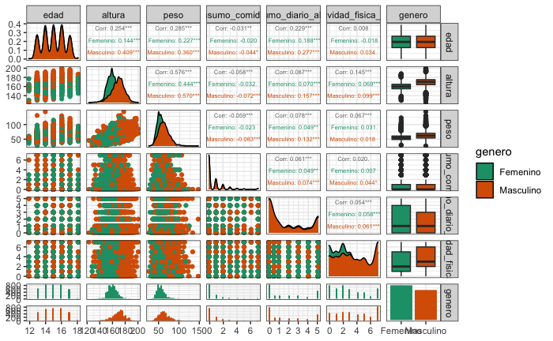

```r
# graficamos con ggpairs coloreando por property type
g <- ggpairs(numeric_train_df, aes(color = genero),
          upper = list(continuous = wrap("cor", size = 2, hjust=0.5)), legend = 25, progress=FALSE) +
  theme(axis.text.x = element_text(angle = 90, hjust = 1), legend.position = "bottom") +
  theme_bw()
# hacemos un loop para cambiar los colores del gráfico
for(i in 1:g$nrow) {
  for(j in 1:g$ncol){
    g[i,j] <- g[i,j] +
      scale_fill_brewer(palette="Dark2") +
      scale_color_brewer(palette="Dark2")
        }
}
g
```

Analizando las variables numéricas y su distribución por género se pueden observar las siguientes relaciones:

- No se observa una fuerte correlación entre las variables. La correlación más fuerte es entre peso y altura con un valor de 0.576
- Se detectan algunas tendencias interesantes que diferencian los hábitos por género:
  - El género masculino realiza más actividad física en promedio que el femenino
  - El peso en el género masculino tiene más varianza, ya que presenta mayor cantidad de outliers en el boxplot y más separados que el género femenino.
  - Sucede lo mismo con la altura, el promedio de la altura masculina es mayor, pero presentan más variabilidad y valores incluso menores que el femenino.

```
Non-numeric variables removed from input: `genero`Correlation computed with
• Method: 'pearson'
• Missing treated using: 'pairwise.complete.obs'
```

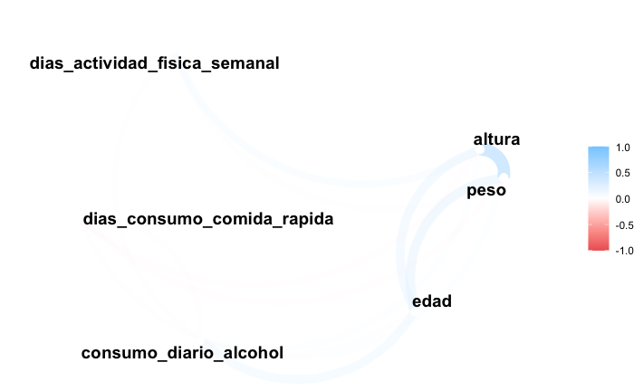

```r
numeric_train_df %>%
 correlate() %>%
  network_plot(min_cor = 0.01)
```

## Variables categóricas

### Transformaciones para graficar de forma legible

Tomo los valores presentes en el dataset y genero una nueva variable asignando un nuevo a cada categoría

```r
encuesta_salud_train_df %>% distinct(frecuencia_hambre_mensual) %>% select(frecuencia_hambre_mensual)
```

| frecuencia_hambre_mensual |
| --- |
| Rara vez |
| Nunca |
| Algunas veces |
| Casi siempre |
| Siempre |
| Dato perdido |

```r
encuesta_salud_train_df %>% distinct(consumo_semanal_verdura) %>% select(consumo_semanal_verdura)
```

| consumo_semanal_verdura |
| --- |
| 4 a 6 veces durante los últimos 7 días |
| 1 vez al día |
| 4 o más veces al día |
| 1 a 3 veces durante los últimos 7 días |
| 2 veces al día |
| No comí verduras ni hortalizas durante los últimos 7 días |
| 3 veces al día |
| Dato perdido |

```r
encuesta_salud_train_df %>% distinct(consumo_semanal_comida_grasa) %>% select(consumo_semanal_comida_grasa)
```

| consumo_semanal_comida_grasa |
| --- |
| No comí comida alta en grasa en los últimos 7 días |
| 4 a 6 veces durante los últimos 7 días |
| 1 a 3 veces durante los últimos 7 días |
| 1 vez al día |
| 2 veces al día |
| 4 o más veces al día |
| 3 veces al día |
| Dato perdido |

```r
encuesta_salud_train_df["verduras"] = encuesta_salud_train_df %>%
  select(consumo_semanal_verdura) %>%
  map(~ str_replace(.x,"No comí verduras ni hortalizas durante los últimos 7 días",'Nunca')) %>%
  map(~ str_replace(.x,"1 vez al día",'1/dia')) %>%
  map(~ str_replace(.x,"2 veces al día",'2/dia')) %>%
  map(~ str_replace(.x,"3 veces al día",'3/dia')) %>%
  map(~ str_replace(.x,"4 o más veces al día",'4+/dia')) %>%
  map(~ str_replace(.x,"Dato perdido",'Perdido')) %>%
  map(~ str_replace(.x,"1 a 3 veces durante los últimos 7 días",'1-3/sem')) %>%
  map(~ str_replace(.x,"4 a 6 veces durante los últimos 7 días",'4-6/sem'))

encuesta_salud_train_df["comida_grasa"] = encuesta_salud_train_df %>%
  select(consumo_semanal_comida_grasa) %>%
  map(~ str_replace(.x,"No comí comida alta en grasa en los últimos 7 días",'Nunca')) %>%
  map(~ str_replace(.x,"1 vez al día",'1/dia')) %>%
  map(~ str_replace(.x,"2 veces al día",'2/dia')) %>%
  map(~ str_replace(.x,"3 veces al día",'3/dia')) %>%
  map(~ str_replace(.x,"4 o más veces al día",'4+/dia')) %>%
  map(~ str_replace(.x,"Dato perdido",'Perdido')) %>%
  map(~ str_replace(.x,"1 a 3 veces durante los últimos 7 días",'1-3/sem')) %>%
  map(~ str_replace(.x,"4 a 6 veces durante los últimos 7 días",'4-6/sem'))

encuesta_salud_train_df["hambre_mensual"] = encuesta_salud_train_df %>%
  select(frecuencia_hambre_mensual) %>%
  map(~ ifelse(.x == "Nunca", 0, .x)) %>%
  map(~ ifelse(.x == "Rara vez", 1, .x)) %>%
  map(~ ifelse(.x == "Algunas veces", 2, .x)) %>%
  map(~ ifelse(.x == "Casi siempre", 3, .x)) %>%
  map(~ ifelse(.x == "Siempre", 4, .x)) %>%
  map(~ ifelse(.x == "Dato perdido", -1, .x))
```

#### Frecuencias relativas

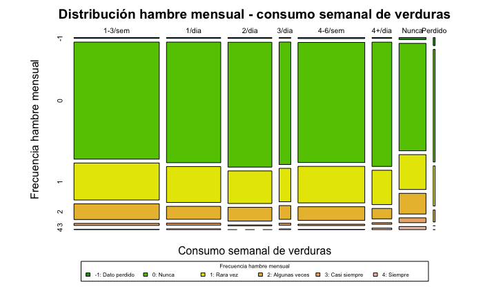

```r
mosaicplot(table(encuesta_salud_train_df$verduras,encuesta_salud_train_df$hambre_mensual),col=terrain.colors(7:11),main="Distribución hambre mensual - consumo semanal de verduras",ylab="Frecuencia hambre mensual",xlab="Consumo semanal de verduras")
legend("bottom",cex=0.5,title="Frecuencia hambre mensual",c("-1: Dato perdido","0: Nunca","1: Rara vez","2: Algunas veces ","3: Casi siempre","4: Siempre"),fill=terrain.colors(7:11),horiz=T,xpd=TRUE,inset=c(0, -0.25))
```

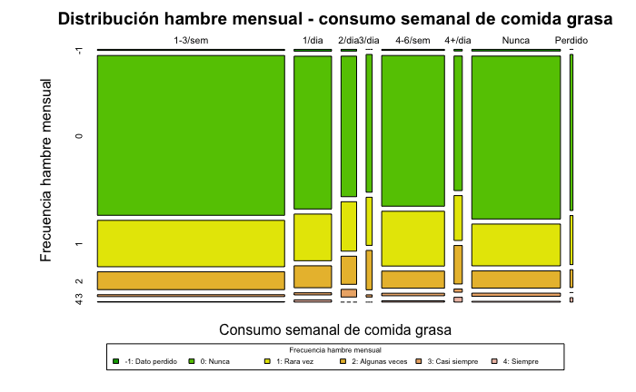

```r
mosaicplot(table(encuesta_salud_train_df$comida_grasa,encuesta_salud_train_df$hambre_mensual),col=terrain.colors(7:11),main="Distribución hambre mensual - consumo semanal de comida grasa",ylab="Frecuencia hambre mensual",xlab="Consumo semanal de comida grasa")
legend("bottom",cex=0.5,title="Frecuencia hambre mensual",c("-1: Dato perdido","0: Nunca","1: Rara vez","2: Algunas veces ","3: Casi siempre","4: Siempre"),fill=terrain.colors(7:11),horiz=T,xpd=TRUE,inset=c(0, -0.25))
```

# Modelo inicial

Se plantea que una primera alternativa para modelar el peso es:

$$\begin{align*}
E(peso) = \beta_0 + \beta_1 altura + \beta_2 edad + \beta_3 genero +
\beta_4 diasActividadFisicaSemanal + \beta_5 consumoDiarioAlcohol
\end{align*}$$

¿Cuál es la interpretación de cada uno de los coeficientes estimados? ¿Son significativos? ¿El modelo resulta significativo para explicar el peso? ¿Qué porcentaje de la variabilidad explica el modelo?

```r
# Cargo los datasets de train y test
encuesta_salud_train_df <- read.csv("datasets/encuesta_salud_train.csv")
encuesta_salud_test_df <- read.csv("datasets/encuesta_salud_test.csv")
```

```r
# ajustamos el modelo lineal múltiple
modelo_inicial = lm(formula = peso ~ altura + edad + genero + dias_actividad_fisica_semanal + consumo_diario_alcohol, data = encuesta_salud_train_df)

# Resumen del modelo
tidy_modelo_inicial <- tidy(modelo_inicial, conf.int = TRUE)
tidy_modelo_inicial
```

| term | estimate | std.error | statistic | p.value | conf.low | conf.high |
| --- | --- | --- | --- | --- | --- | --- |
| (Intercept) | -68.922688070 | 2.33805445 | -29.4786497 | 3.614866e-180 | -73.5059810 | -64.33939510 |
| altura | 0.650606544 | 0.01437975 | 45.2446353 | 0.000000e+00 | 0.6224179 | 0.67879520 |
| edad | 1.406727060 | 0.09385081 | 14.9889709 | 5.121599e-50 | 1.2227511 | 1.59070300 |
| generoMasculino | 1.262643558 | 0.27282821 | 4.6279802 | 3.758831e-06 | 0.7278179 | 1.79746926 |
| dias_actividad_fisica_semanal | -0.087391031 | 0.04992917 | -1.7503000 | 8.011025e-02 | -0.1852673 | 0.01048523 |
| consumo_diario_alcohol | 0.007271379 | 0.06138558 | 0.1184542 | 9.057112e-01 | -0.1130629 | 0.12760566 |

## Interpretación de los coeficientes estimados

- $\beta_0$ (categoría basal de variable categórica género) = -68.922688070 Kg, es la media del peso para las personas de altura = 0, edad = 0, dias_actividad_fisica_semanal = 0, consumo_diario_alcohol = 0 y son de género Femenino, ya que generoMasculino también tiene que ser 0.
- $\beta_0 + \beta_{generoMasculino}$ es la diferencia de los niveles medios del peso para el genero Masculino respecto al generoFemenino, considerando al resto de las variables sin cambio: (-68.922688070 Kg + 1.262643558 Kg = -67.66004 Kg)
- $\beta_1$ indica que para cada incremento en cms del valor de la altura, el peso medio esperado en Kg incrementa en 0.650606544, manteniendo el resto de las variables constantes.
- $\beta_2$ indica que para cada incremento del valor de la edad en años, el peso medio esperado en Kg varia en 1.406727060, manteniendo el resto de las variables constantes.
- $\beta_4$ indica que para cada incremento del valor de la dias_actividad_fisica_semanal en días, el peso medio esperado en Kg varia en -0.087391031, manteniendo el resto de las variables constantes.
- $\beta_5$ indica que para cada unidad que incrementa el valor de la consumo_diario_alcohol, el peso medio esperado en Kg varia en 0.007271379, manteniendo el resto de las variables constantes.

## Significatividad

```r
options("scipen"=1)
tidy_modelo_inicial %>%
  select(term, statistic, p.value, conf.low, conf.high)
```

| term | statistic | p.value | conf.low | conf.high |
| --- | --- | --- | --- | --- |
| (Intercept) | -29.4786497 | 3.614866e-180 | -73.5059810 | -64.33939510 |
| altura | 45.2446353 | 0.000000e+00 | 0.6224179 | 0.67879520 |
| edad | 14.9889709 | 5.121599e-50 | 1.2227511 | 1.59070300 |
| generoMasculino | 4.6279802 | 3.758831e-06 | 0.7278179 | 1.79746926 |
| dias_actividad_fisica_semanal | -1.7503000 | 8.011025e-02 | -0.1852673 | 0.01048523 |
| consumo_diario_alcohol | 0.1184542 | 9.057112e-01 | -0.1130629 | 0.12760566 |

```r
summary(modelo_inicial)
```

```
Call:
lm(formula = peso ~ altura + edad + genero + dias_actividad_fisica_semanal +
    consumo_diario_alcohol, data = encuesta_salud_train_df)

Residuals:
    Min      1Q  Median      3Q     Max
-28.014  -6.527  -1.104   5.050  76.143

Coefficients:
                                Estimate Std. Error t value Pr(>|t|)
(Intercept)                   -68.922688   2.338054 -29.479  < 2e-16 ***
altura                          0.650607   0.014380  45.245  < 2e-16 ***
edad                            1.406727   0.093851  14.989  < 2e-16 ***
generoMasculino                 1.262644   0.272828   4.628 3.76e-06 ***
dias_actividad_fisica_semanal  -0.087391   0.049929  -1.750   0.0801 .
consumo_diario_alcohol          0.007271   0.061386   0.118   0.9057
---
Signif. codes:  0 ‘***’ 0.001 ‘**’ 0.01 ‘*’ 0.05 ‘.’ 0.1 ‘ ’ 1

Residual standard error: 9.914 on 7018 degrees of freedom
Multiple R-squared:  0.3544,    Adjusted R-squared:  0.3539
F-statistic: 770.4 on 5 and 7018 DF,  p-value: < 2.2e-16
```

```r
glance(modelo_inicial)
```

| r.squared | adj.r.squared | sigma | statistic | p.value | df | logLik | AIC | BIC | deviance | df.residual | nobs |
| --- | --- | --- | --- | --- | --- | --- | --- | --- | --- | --- | --- |
| 0.3543754 | 0.3539154 | 9.914373 | 770.4188 | 0 | 5 | -26076.58 | 52167.16 | 52215.15 | 689832.9 | 7018 | 7024 |

En base a los resultados obtenidos, podemos interpretar que el modelo es significativo para explicar el peso de las personas. Observamos que el p-value del Test F es menor a 0.05 (p-value = 2.2e-16).

El $R^{2}$ del modelo es de 0.3539

# Modelo categóricas

Se sugiere probar un modelo que incopore el consumo semanal de snacks y una interacción entre el género y la edad, en lugar de actividad física y consumo de alcohol:

$$\begin{align*}
E(peso) = \beta_0 + \beta_1 altura + \beta_2 edad + \beta_3 genero +
\beta_4 consumoSemanalSnack + \beta_5 genero * edad
\end{align*}$$

Además se pide explícitamente que la categoría “No comí comida salada o snacks en los últimos 7 días” de la variable consumoSemanalSnacks se encuentre como nivel/categoría basal.

¿Cuál es la interpretación de los coeficientes estimados para las categorías de consumoSemanalSnacks y genero * edad? ¿Son significativas? ¿Qué porcentaje de la variabilidad explica el modelo?

En caso de detectar que existen categorías no significativas de la variable consumoSemanalSnacks evaluar si la variable es significativa en su conjunto y, en caso afirmativo, proponer una redefinición de las mismas que permita obtener una mayor proporción de categorías significativas individualmente. Luego, analizar si existen cambios en la variabilidad explicada por el modelo.

## Transfomación categoría basal

```r
# Realizo una transformación simple para definir la categoría basal
encuesta_salud_train_df %>% distinct(consumo_semanal_snacks) %>% select(consumo_semanal_snacks)
```

| consumo_semanal_snacks |
| --- |
| 1 a 3 veces durante los últimos 7 días |
| No comí comida salada o snacks en los últimos 7 días |
| 4 a 6 veces durante los últimos 7 días |
| 1 vez al día |
| Dato perdido |
| 3 veces al día |
| 2 veces al día |
| 4 o más veces al día |

```r
# genero una nueva variable dummy para ubicar la categoría basal
encuesta_salud_train_df["snacksDummy"] = encuesta_salud_train_df %>%
  select(consumo_semanal_snacks) %>%
  map(~ str_replace(.x,"No comí comida salada o snacks en los últimos 7 días",'0')) %>%
  map(~ str_replace(.x,"1 vez al día",'1/dia')) %>%
  map(~ str_replace(.x,"2 veces al día",'2/dia')) %>%
  map(~ str_replace(.x,"3 veces al día",'3/dia')) %>%
  map(~ str_replace(.x,"4 o más veces al día",'4+/dia')) %>%
  map(~ str_replace(.x,"1 a 3 veces durante los últimos 7 días",'1-3/sem')) %>%
  map(~ str_replace(.x,"4 a 6 veces durante los últimos 7 días",'4-6/sem'))
```

```r
modelo_categoricas = lm(formula = peso ~ altura + edad + genero + snacksDummy + (genero * edad), data = encuesta_salud_train_df)

# Resumen del modelo
tidy_modelo_categoricas <- tidy(modelo_categoricas, conf.int = TRUE)
tidy_modelo_categoricas
```

| term | estimate | std.error | statistic | p.value | conf.low | conf.high |
| --- | --- | --- | --- | --- | --- | --- |
| (Intercept) | -64.1994003 | 2.82848788 | -22.697428 | 4.080837e-110 | -69.74409176 | -58.6547088 |
| altura | 0.6429223 | 0.01452916 | 44.250469 | 0.000000e+00 | 0.61444077 | 0.6714039 |
| edad | 1.2230934 | 0.12102373 | 10.106228 | 7.547065e-24 | 0.98585034 | 1.4603365 |
| generoMasculino | -4.6115043 | 2.67876742 | -1.721502 | 8.520382e-02 | -9.86269837 | 0.6396898 |
| snacksDummy1-3/sem | -1.3516324 | 0.27644506 | -4.889334 | 1.034285e-06 | -1.89354827 | -0.8097164 |
| snacksDummy1/dia | -0.6078756 | 0.45601026 | -1.333031 | 1.825651e-01 | -1.50179360 | 0.2860424 |
| snacksDummy2/dia | -1.0946603 | 0.68456905 | -1.599050 | 1.098545e-01 | -2.43662266 | 0.2473020 |
| snacksDummy3/dia | -1.2759618 | 1.01150207 | -1.261452 | 2.071878e-01 | -3.25881168 | 0.7068881 |
| snacksDummy4-6/sem | -2.2700362 | 0.44992485 | -5.045367 | 4.640318e-07 | -3.15202493 | -1.3880474 |
| snacksDummy4+/dia | -2.5669735 | 0.88112366 | -2.913295 | 3.587658e-03 | -4.29424225 | -0.8397047 |

[output cut: 2 more lines]

## Interpretación de los coeficientes estimados

$$\begin{align*}
E(peso) = \beta_0 + \beta_1 altura + \beta_2 edad + \beta_3 genero +
\beta_4 consumoSemanalSnack + \beta_5 genero * edad
\end{align*}$$

- $\beta_0$ (categoría basal de variable categórica género + consumoSemanalSnack) = -64.19940 Kg, es la media del peso para las personas de altura = 0, edad = 0 y son de género Femenino y no han consumido snacks en los últimos 7 días.
- $\beta_1$ indica que para cada incremento en cms del valor de la altura, el peso medio esperado en Kg incrementa en 0.64292, manteniendo el resto de las variables constantes.
- $\beta_2$ indica que para cada incremento del valor de la edad en años, el peso medio esperado en Kg varia en 1.22309, manteniendo el resto de las variables constantes.
- $\beta_0 + \beta_{generoMasculino}$ es la diferencia de los niveles medios del peso para el genero Masculino respecto a la categoría basal, considerando al resto de las variables sin cambio: (-64.19940 Kg -4.61150 Kg = -68.8109 Kg)
- $\beta_0 + \beta_{snacksDummy1-3/sem}$ es la diferencia de los niveles medios del peso para la categoría “1-3/sem” de la variable consumoSemanalSnack respecto a la categoría basal, considerando al resto de las variables sin cambio: (-64.19940 Kg -1.35163 Kg = -65.55103 Kg)
- $\beta_0 + \beta_{snacksDummy1/dia}$ es la diferencia de los niveles medios del peso para la categoría “1/dia” de la variable consumoSemanalSnack respecto a la categoría basal, considerando al resto de las variables sin cambio: (-64.19940 Kg -0.60788 Kg = -64.80728 Kg)
- $\beta_0 + \beta_{snacksDummy2/dia}$ es la diferencia de los niveles medios del peso para la categoría “2/dia” de la variable consumoSemanalSnack respecto a la categoría basal, considerando al resto de las variables sin cambio: (-64.19940 Kg -1.09466 Kg = -65.29406 Kg)
- $\beta_0 + \beta_{snacksDummy3/dia}$ es la diferencia de los niveles medios del peso para la categoría “3/dia” de la variable consumoSemanalSnack respecto a la categoría basal, considerando al resto de las variables sin cambio: (-64.19940 Kg -1.27596 Kg = -65.47536 Kg)
- $\beta_0 + \beta_{snacksDummy4-6/sem}$ es la diferencia de los niveles medios del peso para la categoría “4-6/sem” de la variable consumoSemanalSnack respecto a la categoría basal, considerando al resto de las variables sin cambio: (-64.19940 Kg -2.27004 Kg = -66.46944 Kg)
- $\beta_0 + \beta_{snacksDummy4+/dia}$ es la diferencia de los niveles medios del peso para la categoría “4+/dia” de la variable consumoSemanalSnack respecto a la categoría basal, considerando al resto de las variables sin cambio: (-64.19940 Kg -2.56697 Kg = -66.76637 Kg)
- $\beta_0 + \beta_{snacksDummyDato perdido}$ es la diferencia de los niveles medios del peso para la categoría “Dato perdido” de la variable consumoSemanalSnack respecto a la categoría basal, considerando al resto de las variables sin cambio: (-64.19940 Kg -4.44042 Kg = -68.63982 Kg)
- $\beta_{edad:generoMasculino}$ representa la interacción entre la variable género y edad. En este caso está representando la interacción entre edda y el género másculino, debido a que el género femenino fue considerado como basal. Indica que para cada unidad que incrementa el valor de edad, siendo de género masculino, incrementa el peso medio esperado en Kg en 0.39146, manteniendo el resto de las variables constantes.

## Significatividad

```r
options("scipen"=1)
tidy_modelo_categoricas %>%
  select(term, statistic, p.value, conf.low, conf.high)
```

| term | statistic | p.value | conf.low | conf.high |
| --- | --- | --- | --- | --- |
| (Intercept) | -22.697428 | 4.080837e-110 | -69.74409176 | -58.6547088 |
| altura | 44.250469 | 0.000000e+00 | 0.61444077 | 0.6714039 |
| edad | 10.106228 | 7.547065e-24 | 0.98585034 | 1.4603365 |
| generoMasculino | -1.721502 | 8.520382e-02 | -9.86269837 | 0.6396898 |
| snacksDummy1-3/sem | -4.889334 | 1.034285e-06 | -1.89354827 | -0.8097164 |
| snacksDummy1/dia | -1.333031 | 1.825651e-01 | -1.50179360 | 0.2860424 |
| snacksDummy2/dia | -1.599050 | 1.098545e-01 | -2.43662266 | 0.2473020 |
| snacksDummy3/dia | -1.261452 | 2.071878e-01 | -3.25881168 | 0.7068881 |
| snacksDummy4-6/sem | -5.045367 | 4.640318e-07 | -3.15202493 | -1.3880474 |
| snacksDummy4+/dia | -2.913295 | 3.587658e-03 | -4.29424225 | -0.8397047 |

[output cut: 2 more lines]

```r
summary(modelo_categoricas)
```

```
Call:
lm(formula = peso ~ altura + edad + genero + snacksDummy + (genero *
    edad), data = encuesta_salud_train_df)

Residuals:
    Min      1Q  Median      3Q     Max
-29.005  -6.452  -1.157   5.052  75.767

Coefficients:
                         Estimate Std. Error t value Pr(>|t|)
(Intercept)             -64.19940    2.82849 -22.697  < 2e-16 ***
altura                    0.64292    0.01453  44.250  < 2e-16 ***
edad                      1.22309    0.12102  10.106  < 2e-16 ***
generoMasculino          -4.61150    2.67877  -1.722  0.08520 .
snacksDummy1-3/sem       -1.35163    0.27645  -4.889 1.03e-06 ***
snacksDummy1/dia         -0.60788    0.45601  -1.333  0.18257
snacksDummy2/dia         -1.09466    0.68457  -1.599  0.10985
snacksDummy3/dia         -1.27596    1.01150  -1.261  0.20719
snacksDummy4-6/sem       -2.27004    0.44992  -5.045 4.64e-07 ***
snacksDummy4+/dia        -2.56697    0.88112  -2.913  0.00359 **
snacksDummyDato perdido  -4.44042    1.95125  -2.276  0.02289 *
edad:generoMasculino      0.39146    0.17902   2.187  0.02880 *
---
Signif. codes:  0 ‘***’ 0.001 ‘**’ 0.01 ‘*’ 0.05 ‘.’ 0.1 ‘ ’ 1

Residual standard error: 9.887 on 7012 degrees of freedom
Multiple R-squared:  0.3585,    Adjusted R-squared:  0.3575
F-statistic: 356.3 on 11 and 7012 DF,  p-value: < 2.2e-16
```

```r
glance(modelo_categoricas)
```

| r.squared | adj.r.squared | sigma | statistic | p.value | df | logLik | AIC | BIC | deviance | df.residual | nobs |
| --- | --- | --- | --- | --- | --- | --- | --- | --- | --- | --- | --- |
| 0.3585223 | 0.357516 | 9.886709 | 356.2737 | 0 | 11 | -26053.95 | 52133.89 | 52223.04 | 685402.1 | 7012 | 7024 |

```r
tidy(anova(modelo_categoricas))
```

| term | df | sumsq | meansq | statistic | p.value |
| --- | --- | --- | --- | --- | --- |
| altura | 1 | 354474.0641 | 354474.06410 | 3626.443857 | 0.000000e+00 |
| edad | 1 | 21885.9340 | 21885.93402 | 223.903859 | 7.444135e-50 |
| genero | 1 | 1979.6086 | 1979.60864 | 20.252369 | 6.896484e-06 |
| snacksDummy | 7 | 4264.6404 | 609.23434 | 6.232767 | 2.658835e-07 |
| edad:genero | 1 | 467.3655 | 467.36548 | 4.781378 | 2.880202e-02 |
| Residuals | 7012 | 685402.0731 | 97.74702 | NA | NA |

En base a los resultados obtenidos, podemos interpretar que el modelo es significativo para explicar el peso de las personas. Observamos que el p-value del Test F es menor a 0.05 (p-value = 2.2e-16) y el $R^{2}$ del modelo es de 0.3575, siendo apenas mejor al modelo inicial, analizado en la sección anterior.

Del análisis previo, vemos que 3 categorías no son estadísticamente significativas, pero al revisar los valores del test ANOVA, vemos que la variable en su conjunto sí lo es, por lo que realizaremos una redefinición de las categorías y evaluaremos los resultados obtenidos.

## Redefinición de la variable consumoSemanalSnack

Vamos a redefinir la variable consumo_semanal_snacks en 4 categorías:

- 0: Sin consumo
- Diario: las categorías que indican consumo díario
- Ocacional: las categorías que indican consumo en los últimos 7 días
- Datos perdidos: no presenta cambios a los datos originales

```r
# genero una nueva variable dummy para ubicar la categoría basal
encuesta_salud_train_df["snacksRedefined"] = encuesta_salud_train_df %>%
  select(consumo_semanal_snacks) %>%
  map(~ str_replace(.x,"No comí comida salada o snacks en los últimos 7 días",'0')) %>%
  map(~ str_replace(.x,"1 vez al día",'Diario')) %>%
  map(~ str_replace(.x,"2 veces al día",'Diario')) %>%
  map(~ str_replace(.x,"3 veces al día",'Diario')) %>%
  map(~ str_replace(.x,"4 o más veces al día",'Diario')) %>%
  map(~ str_replace(.x,"1 a 3 veces durante los últimos 7 días",'Ocacional')) %>%
  map(~ str_replace(.x,"4 a 6 veces durante los últimos 7 días",'Ocacional'))
```

Generamos el modelo y analizamos los resultados:

```r
modelo_categoricas_redefined = lm(formula = peso ~ altura + edad + genero + snacksRedefined + (genero * edad), data = encuesta_salud_train_df)

# Resumen del modelo
tidy(modelo_categoricas_redefined, conf.int = TRUE)
```

| term | estimate | std.error | statistic | p.value | conf.low | conf.high |
| --- | --- | --- | --- | --- | --- | --- |
| (Intercept) | -64.2047183 | 2.8286369 | -22.698112 | 4.002347e-110 | -69.74970133 | -58.6597352 |
| altura | 0.6430807 | 0.0145308 | 44.256391 | 0.000000e+00 | 0.61459598 | 0.6715655 |
| edad | 1.2217318 | 0.1210511 | 10.092694 | 8.644947e-24 | 0.98443502 | 1.4590285 |
| generoMasculino | -4.6910533 | 2.6771733 | -1.752241 | 7.977603e-02 | -9.93912201 | 0.5570154 |
| snacksRedefinedDato perdido | -4.4389581 | 1.9519280 | -2.274140 | 2.298762e-02 | -8.26532679 | -0.6125894 |
| snacksRedefinedDiario | -1.0206313 | 0.3706811 | -2.753395 | 5.913254e-03 | -1.74727824 | -0.2939844 |
| snacksRedefinedOcacional | -1.5036169 | 0.2670495 | -5.630480 | 1.866559e-08 | -2.02711458 | -0.9801192 |
| edad:generoMasculino | 0.3967101 | 0.1789215 | 2.217230 | 2.663934e-02 | 0.04596985 | 0.7474504 |

```r
summary(modelo_categoricas_redefined)
```

```
Call:
lm(formula = peso ~ altura + edad + genero + snacksRedefined +
    (genero * edad), data = encuesta_salud_train_df)

Residuals:
    Min      1Q  Median      3Q     Max
-29.015  -6.447  -1.153   5.096  75.769

Coefficients:
                             Estimate Std. Error t value Pr(>|t|)
(Intercept)                 -64.20472    2.82864 -22.698  < 2e-16 ***
altura                        0.64308    0.01453  44.256  < 2e-16 ***
edad                          1.22173    0.12105  10.093  < 2e-16 ***
generoMasculino              -4.69105    2.67717  -1.752  0.07978 .
snacksRedefinedDato perdido  -4.43896    1.95193  -2.274  0.02299 *
snacksRedefinedDiario        -1.02063    0.37068  -2.753  0.00591 **
snacksRedefinedOcacional     -1.50362    0.26705  -5.630 1.87e-08 ***
edad:generoMasculino          0.39671    0.17892   2.217  0.02664 *
---
Signif. codes:  0 ‘***’ 0.001 ‘**’ 0.01 ‘*’ 0.05 ‘.’ 0.1 ‘ ’ 1

Residual standard error: 9.89 on 7016 degrees of freedom
Multiple R-squared:  0.3577,    Adjusted R-squared:  0.3571
F-statistic: 558.2 on 7 and 7016 DF,  p-value: < 2.2e-16
```

```r
tidy(anova(modelo_categoricas_redefined))
```

| term | df | sumsq | meansq | statistic | p.value |
| --- | --- | --- | --- | --- | --- |
| altura | 1 | 354474.0641 | 354474.06410 | 3623.915050 | 0.000000e+00 |
| edad | 1 | 21885.9340 | 21885.93402 | 223.747726 | 8.023934e-50 |
| genero | 1 | 1979.6086 | 1979.60864 | 20.238247 | 6.947370e-06 |
| snacksRedefined | 3 | 3381.5939 | 1127.19798 | 11.523748 | 1.562125e-07 |
| edad:genero | 1 | 480.8701 | 480.87010 | 4.916107 | 2.663934e-02 |
| Residuals | 7016 | 686271.6149 | 97.81522 | NA | NA |

Podemos observar que al agrupar las categorías, mejora la significatividad, el modelo continua siendo significativo para explicar el peso de las personas y el $R^{2}$ del modelo es de 0.3571, siendo apenas menor al modelo original.

# Modelos propios y evaluación

Realizar 2 modelos lineales múltiples adicionales y explicar brevemente la lógica detrás de los mismos (se valorará la creación y/o inclusión de variables nuevas).

Evaluar la performance del modelo inicial, el modelo categóricas con las categorías redefinidas de la variable consumoSemanalSnacks y los modelos desarrollados en este punto en el dataset de entrenamiento y evaluación (usar dataset “encuesta_salud_test.csv”).

La evaluación de performance consiste en comparar la performance en términos del R cuadrado ajustado, RMSE y MAE sobre el set de entrenamiento y en términos de RMSE y MAE sobre el set de evaluación.

¿Cuál es el mejor modelo para nuestro objetivo de predecir el peso? ¿Por qué?

## Primer modelo

En el primer modelo vamos a incoporar una interacción entre las variables genero y altura, ya que en el análisis exploratorio se observó una clara diferencia en los valores medios de la altura al agruparlos por género, por lo que es un indicador de que existe una correlación y es interesante analizar el impacto en el modelo al incluir esta interacción. Además de este nuevo $\beta$, se mantendras la variable edad.

$$\begin{align*}
E(peso) = \beta_0 + \beta_1 altura + \beta_2 edad + \beta_3 genero +
\beta_4 genero * altura
\end{align*}$$

```r
my_first_model = lm(formula = peso ~ altura + edad + genero + (genero * altura), data = encuesta_salud_train_df)

tidy(my_first_model)
```

| term | estimate | std.error | statistic | p.value |
| --- | --- | --- | --- | --- |
| (Intercept) | -58.6425598 | 3.65582455 | -16.040857 | 6.740027e-57 |
| altura | 0.5874018 | 0.02208909 | 26.592396 | 1.558301e-148 |
| edad | 1.3795947 | 0.09215170 | 14.970910 | 6.662866e-50 |
| generoMasculino | -15.5670558 | 4.63204122 | -3.360733 | 7.815065e-04 |
| altura:generoMasculino | 0.1025084 | 0.02824190 | 3.629657 | 2.858172e-04 |

### Evaluación de performance

Primero evaluamos los $R^2$ ajustado de los 3 modelos y vemos que son muy parecidos, recién en el tercer decimal notamos una diferencia.

```r
cmp_model_list_1 <- list(modelo_inicial = modelo_inicial, modelo_cat_redefinido = modelo_categoricas_redefined, modelo_propio = my_first_model)
# calculamos las métricas para todos los modelos
glance_train_1 = map_df(cmp_model_list_1, broom::glance, .id = "model") %>%
  # ordenamos por R2 ajustado
  arrange(desc(adj.r.squared))
glance_train_1
```

| model | r.squared | adj.r.squared | sigma | statistic | p.value | df | logLik | AIC | BIC | deviance | df.residual | nobs |
| --- | --- | --- | --- | --- | --- | --- | --- | --- | --- | --- | --- | --- |
| modelo_cat_redefinido | 0.3577085 | 0.3570676 | 9.890158 | 558.1983 | 0 | 7 | -26058.40 | 52134.80 | 52196.51 | 686271.6 | 7016 | 7024 |
| modelo_propio | 0.3553036 | 0.3549362 | 9.906538 | 967.0738 | 0 | 4 | -26071.52 | 52155.05 | 52196.19 | 688841.1 | 7019 | 7024 |
| modelo_inicial | 0.3543754 | 0.3539154 | 9.914373 | 770.4188 | 0 | 5 | -26076.58 | 52167.16 | 52215.15 | 689832.9 | 7018 | 7024 |

```r
# Aplicamos la función augment a los modelos
training_predictions_1 = map(.x = cmp_model_list_1, .f = augment)

# Obtenemos el RMSE para los 4 modelos
map_df(.x = training_predictions_1, .f = metrics, truth = peso, estimate = .fitted, .id="modelo") %>% arrange(.metric,.estimate)
```

| modelo | .metric | .estimator | .estimate |
| --- | --- | --- | --- |
| modelo_cat_redefinido | mae | standard | 7.4392788 |
| modelo_propio | mae | standard | 7.4463537 |
| modelo_inicial | mae | standard | 7.4552017 |
| modelo_cat_redefinido | rmse | standard | 9.8845241 |
| modelo_propio | rmse | standard | 9.9030116 |
| modelo_inicial | rmse | standard | 9.9101379 |
| modelo_inicial | rsq | standard | 0.3543754 |
| modelo_propio | rsq | standard | 0.3553036 |
| modelo_cat_redefinido | rsq | standard | 0.3577085 |

Se observa que el modelo que obtiene el menor RMSE y MAE es el modelo de categóricas redefinidas y esto coincide con los resultados del $R^2$ ajustado, siendo este modelo el que mayor valor tiene.

Ahora evaluaremos las métricas de los modelos en el dataset de testing:

```r
# genero una nueva variable dummy para ubicar la categoría basal
encuesta_salud_test_df["snacksRedefined"] = encuesta_salud_test_df %>%
  select(consumo_semanal_snacks) %>%
  map(~ str_replace(.x,"No comí comida salada o snacks en los últimos 7 días",'0')) %>%
  map(~ str_replace(.x,"1 vez al día",'Diario')) %>%
  map(~ str_replace(.x,"2 veces al día",'Diario')) %>%
  map(~ str_replace(.x,"3 veces al día",'Diario')) %>%
  map(~ str_replace(.x,"4 o más veces al día",'Diario')) %>%
  map(~ str_replace(.x,"1 a 3 veces durante los últimos 7 días",'Ocacional')) %>%
  map(~ str_replace(.x,"4 a 6 veces durante los últimos 7 días",'Ocacional'))

# Aplicamos la función augment a los 4 modelos con el set de testing
testing_predicciones_1 = map(.x = cmp_model_list_1, .f = augment, newdata = encuesta_salud_test_df)

# Obtenemos el RMSE para los 4 modelos
map_dfr(.x = testing_predicciones_1, .f = metrics, truth = peso, estimate = .fitted, .id="modelo") %>% arrange(.metric,.estimate)
```

| modelo | .metric | .estimator | .estimate |
| --- | --- | --- | --- |
| modelo_cat_redefinido | mae | standard | 7.5571251 |
| modelo_propio | mae | standard | 7.5674590 |
| modelo_inicial | mae | standard | 7.5780283 |
| modelo_cat_redefinido | rmse | standard | 10.1863511 |
| modelo_propio | rmse | standard | 10.2080601 |
| modelo_inicial | rmse | standard | 10.2121115 |
| modelo_inicial | rsq | standard | 0.3433755 |
| modelo_propio | rsq | standard | 0.3438924 |
| modelo_cat_redefinido | rsq | standard | 0.3467211 |

El modelo que tiene las mejores métrias en testing continúa siendo el modelo de categóricas redefinidas. Siendo mínima la diferencia con los otros modelos.

Siguiendo estos resultados, el modelo a elegir para las predicciones del peso en datos nuevos es el modelo de categóricas redefinidas, ya que explican un 34.67% de la variabilidad del peso y tienen el menor valor en las métricas de error MAE y RMSE.

## Seguno modelo

En el segundo modelo vamos a incorporar el consumo al modelo anterior, generando 2 nuevas variables “comidaSana” y “comidaChatarra” que serán una combinación de las variables de consumo existentes en el dataset. Adicionalmente, se incluirán los días de consumo de comida rápida.

- comidaSana: combinación de consumo_semanal_frutas y consumo_semanal_verdura
- comidaChatarra: combinación de consumo_semanal_snacks y consumo_semanal_comida_grasa

$$\begin{align*}
E(peso) = \beta_0 + \beta_1 altura + \beta_2 edad + \beta_3 genero +
\beta_4 genero * altura + \beta_5 comidaSana + \beta_6 comidaChatarra +
\beta_7 diasConsumoComidaRapida
\end{align*}$$

### Generación de las variables nuevas

Partimos de la redefinición realizada en el modelo de categóricas y lo extendemos a las otras variables categóricas de consumo. Luego se realizó una combinación de estas variables en una nuevo, intentando “promediar” las categorías. Las nuevas categorías son:

- 0: no consumieron ninguno de ambas variables (se mantiene la lógica para utilizarlo de categoría basal)
- Diario: consumo diario en ambas variables
- Ocacional: consumieron alguna vez en los últimos 7 días en ambas variables
- SemiDiario: consumieron diariamente en alguna de las variables
- SemiOcacional: consumieron ocacionalmente en alguna de las variables
- Dato perdido: no se dispone del dato en alguna de las variables
- Otro: en caso de no cubrir alguna de los escenarios anteriores

#### Dataset de train

```r
# genero una nueva variable dummy para ubicar la categoría basal
encuesta_salud_train_df["snacksRedefined"] = encuesta_salud_train_df %>%
  select(consumo_semanal_snacks) %>%
  map(~ str_replace(.x,"No comí comida salada o snacks en los últimos 7 días",'0')) %>%
  map(~ str_replace(.x,"1 vez al día",'Diario')) %>%
  map(~ str_replace(.x,"2 veces al día",'Diario')) %>%
  map(~ str_replace(.x,"3 veces al día",'Diario')) %>%
  map(~ str_replace(.x,"4 o más veces al día",'Diario')) %>%
  map(~ str_replace(.x,"1 a 3 veces durante los últimos 7 días",'Ocacional')) %>%
  map(~ str_replace(.x,"4 a 6 veces durante los últimos 7 días",'Ocacional'))

encuesta_salud_train_df["verdurasRedefined"] = encuesta_salud_train_df %>%
  select(consumo_semanal_verdura) %>%
  map(~ str_replace(.x,"No comí verduras ni hortalizas durante los últimos 7 días",'0')) %>%
  map(~ str_replace(.x,"1 vez al día",'Diario')) %>%
  map(~ str_replace(.x,"2 veces al día",'Diario')) %>%
  map(~ str_replace(.x,"3 veces al día",'Diario')) %>%
  map(~ str_replace(.x,"4 o más veces al día",'Diario')) %>%
  map(~ str_replace(.x,"1 a 3 veces durante los últimos 7 días",'Ocacional')) %>%
  map(~ str_replace(.x,"4 a 6 veces durante los últimos 7 días",'Ocacional'))

encuesta_salud_train_df["frutasRedefined"] = encuesta_salud_train_df %>%
  select(consumo_semanal_frutas) %>%
  map(~ str_replace(.x,"No comí frutas durante los últimos 7 días",'0')) %>%
  map(~ str_replace(.x,"1 vez al día",'Diario')) %>%
  map(~ str_replace(.x,"2 veces al día",'Diario')) %>%
  map(~ str_replace(.x,"3 veces al día",'Diario')) %>%
  map(~ str_replace(.x,"4 o más veces al día",'Diario')) %>%
  map(~ str_replace(.x,"1 a 3 veces durante los últimos 7 días",'Ocacional')) %>%
  map(~ str_replace(.x,"4 a 6 veces durante los últimos 7 días",'Ocacional'))

encuesta_salud_train_df["grasasRedefined"] = encuesta_salud_train_df %>%
  select(consumo_semanal_comida_grasa) %>%
  map(~ str_replace(.x,"No comí comida alta en grasa en los últimos 7 días",'0')) %>%
  map(~ str_replace(.x,"1 vez al día",'Diario')) %>%
  map(~ str_replace(.x,"2 veces al día",'Diario')) %>%
  map(~ str_replace(.x,"3 veces al día",'Diario')) %>%
  map(~ str_replace(.x,"4 o más veces al día",'Diario')) %>%
  map(~ str_replace(.x,"1 a 3 veces durante los últimos 7 días",'Ocacional')) %>%
  map(~ str_replace(.x,"4 a 6 veces durante los últimos 7 días",'Ocacional'))

encuesta_salud_train_df %>% distinct(verdurasRedefined) %>% select(verdurasRedefined)
```

| verdurasRedefined |
| --- |
| Ocacional |
| Diario |
| 0 |
| Dato perdido |

```r
encuesta_salud_train_df %>% distinct(frutasRedefined) %>% select(frutasRedefined)
```

| frutasRedefined |
| --- |
| 0 |
| Ocacional |
| Diario |
| Dato perdido |

```r
encuesta_salud_train_df %>% distinct(grasasRedefined) %>% select(grasasRedefined)
```

| grasasRedefined |
| --- |
| 0 |
| Ocacional |
| Diario |
| Dato perdido |

```r
encuesta_salud_train_df %>% distinct(snacksRedefined) %>% select(snacksRedefined)
```

| snacksRedefined |
| --- |
| Ocacional |
| 0 |
| Diario |
| Dato perdido |

```r
encuesta_salud_train_df = encuesta_salud_train_df %>%
  mutate(comidaSana = if_else(frutasRedefined == '0' & verdurasRedefined == '0', '0',
                  if_else(frutasRedefined == 'Diario' & verdurasRedefined == 'Diario', 'Diario',
                  if_else(frutasRedefined == 'Ocacional' & verdurasRedefined == 'Ocacional', 'Ocacional',
                  if_else(frutasRedefined == 'Dato perdido' | verdurasRedefined == 'Dato perdido', 'Dato perdido',
                  if_else(frutasRedefined == 'Diario' | verdurasRedefined == 'Diario', 'SemiDiario',
                  if_else(frutasRedefined == 'Ocacional' | verdurasRedefined == 'Ocacional', 'SemiOcacional',
                          'Otro'
                         )))))))  %>%
  mutate(comidaChatarra = if_else(snacksRedefined == '0' & grasasRedefined == '0', '0',
                  if_else(snacksRedefined == 'Diario' & grasasRedefined == 'Diario', 'Diario',
                  if_else(snacksRedefined == 'Ocacional' & grasasRedefined == 'Ocacional', 'Ocacional',
                  if_else(snacksRedefined == 'Dato perdido' | grasasRedefined == 'Dato perdido', 'Dato perdido',
                  if_else(snacksRedefined == 'Diario' | grasasRedefined == 'Diario', 'SemiDiario',
                  if_else(snacksRedefined == 'Ocacional' | grasasRedefined == 'Ocacional', 'SemiOcacional',
                          'Otro'
                         )))))))


encuesta_salud_train_df %>% distinct(comidaSana) %>% select(comidaSana)
```

| comidaSana |
| --- |
| SemiOcacional |
| SemiDiario |
| Diario |
| 0 |
| Ocacional |
| Dato perdido |

```r
encuesta_salud_train_df %>% distinct(comidaChatarra) %>% select(comidaChatarra)
```

| comidaChatarra |
| --- |
| SemiOcacional |
| Ocacional |
| SemiDiario |
| 0 |
| Diario |
| Dato perdido |

#### Dataset de test

```r
# genero una nueva variable dummy para ubicar la categoría basal
encuesta_salud_test_df["snacksRedefined"] = encuesta_salud_test_df %>%
  select(consumo_semanal_snacks) %>%
  map(~ str_replace(.x,"No comí comida salada o snacks en los últimos 7 días",'0')) %>%
  map(~ str_replace(.x,"1 vez al día",'Diario')) %>%
  map(~ str_replace(.x,"2 veces al día",'Diario')) %>%
  map(~ str_replace(.x,"3 veces al día",'Diario')) %>%
  map(~ str_replace(.x,"4 o más veces al día",'Diario')) %>%
  map(~ str_replace(.x,"1 a 3 veces durante los últimos 7 días",'Ocacional')) %>%
  map(~ str_replace(.x,"4 a 6 veces durante los últimos 7 días",'Ocacional'))

encuesta_salud_test_df["verdurasRedefined"] = encuesta_salud_test_df %>%
  select(consumo_semanal_verdura) %>%
  map(~ str_replace(.x,"No comí verduras ni hortalizas durante los últimos 7 días",'0')) %>%
  map(~ str_replace(.x,"1 vez al día",'Diario')) %>%
  map(~ str_replace(.x,"2 veces al día",'Diario')) %>%
  map(~ str_replace(.x,"3 veces al día",'Diario')) %>%
  map(~ str_replace(.x,"4 o más veces al día",'Diario')) %>%
  map(~ str_replace(.x,"1 a 3 veces durante los últimos 7 días",'Ocacional')) %>%
  map(~ str_replace(.x,"4 a 6 veces durante los últimos 7 días",'Ocacional'))

encuesta_salud_test_df["frutasRedefined"] = encuesta_salud_test_df %>%
  select(consumo_semanal_frutas) %>%
  map(~ str_replace(.x,"No comí frutas durante los últimos 7 días",'0')) %>%
  map(~ str_replace(.x,"1 vez al día",'Diario')) %>%
  map(~ str_replace(.x,"2 veces al día",'Diario')) %>%
  map(~ str_replace(.x,"3 veces al día",'Diario')) %>%
  map(~ str_replace(.x,"4 o más veces al día",'Diario')) %>%
  map(~ str_replace(.x,"1 a 3 veces durante los últimos 7 días",'Ocacional')) %>%
  map(~ str_replace(.x,"4 a 6 veces durante los últimos 7 días",'Ocacional'))

encuesta_salud_test_df["grasasRedefined"] = encuesta_salud_test_df %>%
  select(consumo_semanal_comida_grasa) %>%
  map(~ str_replace(.x,"No comí comida alta en grasa en los últimos 7 días",'0')) %>%
  map(~ str_replace(.x,"1 vez al día",'Diario')) %>%
  map(~ str_replace(.x,"2 veces al día",'Diario')) %>%
  map(~ str_replace(.x,"3 veces al día",'Diario')) %>%
  map(~ str_replace(.x,"4 o más veces al día",'Diario')) %>%
  map(~ str_replace(.x,"1 a 3 veces durante los últimos 7 días",'Ocacional')) %>%
  map(~ str_replace(.x,"4 a 6 veces durante los últimos 7 días",'Ocacional'))

encuesta_salud_test_df %>% distinct(verdurasRedefined) %>% select(verdurasRedefined)
```

| verdurasRedefined |
| --- |
| Ocacional |
| Dato perdido |
| Diario |
| 0 |

```r
encuesta_salud_test_df %>% distinct(frutasRedefined) %>% select(frutasRedefined)
```

| frutasRedefined |
| --- |
| Diario |
| 0 |
| Ocacional |
| Dato perdido |

```r
encuesta_salud_test_df %>% distinct(grasasRedefined) %>% select(grasasRedefined)
```

| grasasRedefined |
| --- |
| 0 |
| Ocacional |
| Diario |
| Dato perdido |

```r
encuesta_salud_test_df %>% distinct(snacksRedefined) %>% select(snacksRedefined)
```

| snacksRedefined |
| --- |
| 0 |
| Diario |
| Ocacional |
| Dato perdido |

```r
encuesta_salud_test_df = encuesta_salud_test_df %>%
  mutate(comidaSana = if_else(frutasRedefined == '0' & verdurasRedefined == '0', '0',
                  if_else(frutasRedefined == 'Diario' & verdurasRedefined == 'Diario', 'Diario',
                  if_else(frutasRedefined == 'Ocacional' & verdurasRedefined == 'Ocacional', 'Ocacional',
                  if_else(frutasRedefined == 'Dato perdido' | verdurasRedefined == 'Dato perdido', 'Dato perdido',
                  if_else(frutasRedefined == 'Diario' | verdurasRedefined == 'Diario', 'SemiDiario',
                  if_else(frutasRedefined == 'Ocacional' | verdurasRedefined == 'Ocacional', 'SemiOcacional',
                          'Otro'
                         )))))))  %>%
  mutate(comidaChatarra = if_else(snacksRedefined == '0' & grasasRedefined == '0', '0',
                  if_else(snacksRedefined == 'Diario' & grasasRedefined == 'Diario', 'Diario',
                  if_else(snacksRedefined == 'Ocacional' & grasasRedefined == 'Ocacional', 'Ocacional',
                  if_else(snacksRedefined == 'Dato perdido' | grasasRedefined == 'Dato perdido', 'Dato perdido',
                  if_else(snacksRedefined == 'Diario' | grasasRedefined == 'Diario', 'SemiDiario',
                  if_else(snacksRedefined == 'Ocacional' | grasasRedefined == 'Ocacional', 'SemiOcacional',
                          'Otro'
                         )))))))


encuesta_salud_test_df %>% distinct(comidaSana) %>% select(comidaSana)
```

| comidaSana |
| --- |
| SemiDiario |
| Dato perdido |
| Diario |
| SemiOcacional |
| Ocacional |
| 0 |

```r
encuesta_salud_test_df %>% distinct(comidaChatarra) %>% select(comidaChatarra)
```

| comidaChatarra |
| --- |
| 0 |
| SemiDiario |
| Ocacional |
| SemiOcacional |
| Diario |
| Dato perdido |

### Generación del modelo

$$\begin{align*}
E(peso) = \beta_0 + \beta_1 altura + \beta_2 edad + \beta_3 genero +
\beta_4 genero * altura + \beta_5 comidaSana + \beta_6 comidaChatarra +
\beta_7 diasConsumoComidaRapida
\end{align*}$$

```r
my_model_2 = lm(formula = peso ~ altura + edad + genero + (genero * altura) + comidaSana + comidaChatarra + dias_consumo_comida_rapida, data = encuesta_salud_train_df)
```

Evaluamos los resultados del modelo:

```r
summary(my_model_2)
```

```
Call:
lm(formula = peso ~ altura + edad + genero + (genero * altura) +
    comidaSana + comidaChatarra + dias_consumo_comida_rapida,
    data = encuesta_salud_train_df)

Residuals:
    Min      1Q  Median      3Q     Max
-28.885  -6.473  -1.127   5.088  75.027

Coefficients:
                             Estimate Std. Error t value Pr(>|t|)
(Intercept)                 -57.25058    3.73178 -15.341  < 2e-16 ***
altura                        0.58789    0.02209  26.613  < 2e-16 ***
edad                          1.37332    0.09214  14.904  < 2e-16 ***
generoMasculino             -15.54972    4.62862  -3.359 0.000785 ***
comidaSanaDato perdido        0.20122    1.47351   0.137 0.891383
comidaSanaDiario             -1.14239    0.73865  -1.547 0.122007
comidaSanaOcacional          -0.69028    0.73251  -0.942 0.346046
comidaSanaSemiDiario         -0.82328    0.72327  -1.138 0.255049
comidaSanaSemiOcacional      -1.15089    0.76211  -1.510 0.131053
comidaChatarraDato perdido   -3.35661    1.26075  -2.662 0.007777 **
comidaChatarraDiario          0.14624    0.57357   0.255 0.798753
comidaChatarraOcacional      -0.90015    0.42075  -2.139 0.032437 *
comidaChatarraSemiDiario     -0.32528    0.47629  -0.683 0.494669
comidaChatarraSemiOcacional   0.21948    0.43769   0.501 0.616069
dias_consumo_comida_rapida   -0.18689    0.08839  -2.114 0.034516 *
altura:generoMasculino        0.10240    0.02822   3.628 0.000287 ***
---
Signif. codes:  0 ‘***’ 0.001 ‘**’ 0.01 ‘*’ 0.05 ‘.’ 0.1 ‘ ’ 1

Residual standard error: 9.891 on 7008 degrees of freedom
Multiple R-squared:  0.3583,    Adjusted R-squared:  0.3569
F-statistic: 260.8 on 15 and 7008 DF,  p-value: < 2.2e-16
```

```r
anova(my_model_2)
```

```
Analysis of Variance Table

Response: peso
                             Df Sum Sq Mean Sq   F value    Pr(>F)
altura                        1 354474  354474 3622.9340 < 2.2e-16 ***
edad                          1  21886   21886  223.6872 < 2.2e-16 ***
genero                        1   1980    1980   20.2328 6.967e-06 ***
comidaSana                    5    448      90    0.9158 0.4694809
comidaChatarra                5   2271     454    4.6419 0.0003124 ***
dias_consumo_comida_rapida    1    452     452    4.6232 0.0315765 *
altura:genero                 1   1288    1288   13.1659 0.0002871 ***
Residuals                  7008 685675      98
---
Signif. codes:  0 ‘***’ 0.001 ‘**’ 0.01 ‘*’ 0.05 ‘.’ 0.1 ‘ ’ 1
```

Vemos que la variable comidaSana parece no ser estadísticamente significativa, en cambio comidaChatarra en su conjunto sí. Por lo que probaremos hacer un ajuste quitando esa variable y generando una interacción entre el consumo de comidaChatarra y los dias de consumo de comida rápida.

$$\begin{align*}
E(peso) = \beta_0 + \beta_1 altura + \beta_2 edad + \beta_3 genero +
\beta_4 genero * altura + \beta_6 comidaChatarra *
diasConsumoComidaRapida
\end{align*}$$

```r
my_model_2_ajustado = lm(formula = peso ~ altura + edad + genero + (genero * altura)  + (comidaChatarra * dias_consumo_comida_rapida), data = encuesta_salud_train_df)
```

```r
summary(my_model_2_ajustado)
```

```
Call:
lm(formula = peso ~ altura + edad + genero + (genero * altura) +
    (comidaChatarra * dias_consumo_comida_rapida), data = encuesta_salud_train_df)

Residuals:
    Min      1Q  Median      3Q     Max
-28.764  -6.424  -1.127   5.096  75.924

Coefficients:
                                                         Estimate Std. Error t value Pr(>|t|)
(Intercept)                                            -57.956805   3.677750 -15.759  < 2e-16 ***
altura                                                   0.586538   0.022100  26.540  < 2e-16 ***
edad                                                     1.370483   0.092059  14.887  < 2e-16 ***
generoMasculino                                        -15.963160   4.630462  -3.447 0.000569 ***
comidaChatarraDato perdido                              -3.942173   1.459820  -2.700 0.006941 **
comidaChatarraDiario                                    -0.009638   0.666812  -0.014 0.988469
comidaChatarraOcacional                                 -0.596435   0.449407  -1.327 0.184499
comidaChatarraSemiDiario                                -0.268353   0.523037  -0.513 0.607921
comidaChatarraSemiOcacional                              0.233952   0.467158   0.501 0.616529
dias_consumo_comida_rapida                              -0.003144   0.399749  -0.008 0.993726
altura:generoMasculino                                   0.104909   0.028232   3.716 0.000204 ***
comidaChatarraDato perdido:dias_consumo_comida_rapida    0.428342   0.747755   0.573 0.566773
comidaChatarraDiario:dias_consumo_comida_rapida         -0.056572   0.453057  -0.125 0.900632
comidaChatarraOcacional:dias_consumo_comida_rapida      -0.440512   0.429427  -1.026 0.305015
comidaChatarraSemiDiario:dias_consumo_comida_rapida     -0.162281   0.437065  -0.371 0.710427
comidaChatarraSemiOcacional:dias_consumo_comida_rapida  -0.018256   0.446842  -0.041 0.967412
---
Signif. codes:  0 ‘***’ 0.001 ‘**’ 0.01 ‘*’ 0.05 ‘.’ 0.1 ‘ ’ 1

Residual standard error: 9.891 on 7008 degrees of freedom
Multiple R-squared:  0.3583,    Adjusted R-squared:  0.3569
F-statistic: 260.8 on 15 and 7008 DF,  p-value: < 2.2e-16
```

```r
anova(my_model_2_ajustado)
```

```
Analysis of Variance Table

Response: peso
                                            Df Sum Sq Mean Sq   F value    Pr(>F)
altura                                       1 354474  354474 3622.9463 < 2.2e-16 ***
edad                                         1  21886   21886  223.6879 < 2.2e-16 ***
genero                                       1   1980    1980   20.2328 6.967e-06 ***
comidaChatarra                               5   2206     441    4.5084 0.0004186 ***
dias_consumo_comida_rapida                   1    458     458    4.6803 0.0305448 *
altura:genero                                1   1320    1320   13.4951 0.0002410 ***
comidaChatarra:dias_consumo_comida_rapida    5    478      96    0.9768 0.4302641
Residuals                                 7008 685672      98
---
Signif. codes:  0 ‘***’ 0.001 ‘**’ 0.01 ‘*’ 0.05 ‘.’ 0.1 ‘ ’ 1
```

Ahora observamos que la interacción parece no ser significativa, pero la variable dias_consumo_comida_rapida es levemente significativa, por lo que haremos un segundo ajuste y solamente probar un modelo con la variable comidaChatarra.

$$\begin{align*}
E(peso) = \beta_0 + \beta_1 altura + \beta_2 edad + \beta_3 genero +
\beta_4 genero * altura + \beta_6 comidaChatarra
\end{align*}$$

```r
my_model_2_reducido = lm(formula = peso ~ altura + edad + genero + (genero * altura) + comidaChatarra, data = encuesta_salud_train_df)
```

```r
summary(my_model_2_reducido)
```

```
Call:
lm(formula = peso ~ altura + edad + genero + (genero * altura) +
    comidaChatarra, data = encuesta_salud_train_df)

Residuals:
    Min      1Q  Median      3Q     Max
-28.780  -6.475  -1.105   5.062  76.081

Coefficients:
                             Estimate Std. Error t value Pr(>|t|)
(Intercept)                 -58.27751    3.67194 -15.871  < 2e-16 ***
altura                        0.58811    0.02208  26.634  < 2e-16 ***
edad                          1.37444    0.09205  14.931  < 2e-16 ***
generoMasculino             -15.84977    4.62775  -3.425 0.000618 ***
comidaChatarraDato perdido   -3.44988    1.25536  -2.748 0.006009 **
comidaChatarraDiario         -0.09979    0.56230  -0.177 0.859143
comidaChatarraOcacional      -0.92216    0.41375  -2.229 0.025860 *
comidaChatarraSemiDiario     -0.43870    0.47151  -0.930 0.352189
comidaChatarraSemiOcacional   0.22180    0.43424   0.511 0.609533
altura:generoMasculino        0.10426    0.02822   3.695 0.000221 ***
---
Signif. codes:  0 ‘***’ 0.001 ‘**’ 0.01 ‘*’ 0.05 ‘.’ 0.1 ‘ ’ 1

Residual standard error: 9.894 on 7014 degrees of freedom
Multiple R-squared:  0.3574,    Adjusted R-squared:  0.3566
F-statistic: 433.5 on 9 and 7014 DF,  p-value: < 2.2e-16
```

```r
anova(my_model_2_reducido)
```

```
Analysis of Variance Table

Response: peso
                 Df Sum Sq Mean Sq   F value    Pr(>F)
altura            1 354474  354474 3621.1921 < 2.2e-16 ***
edad              1  21886   21886  223.5796 < 2.2e-16 ***
genero            1   1980    1980   20.2230 7.003e-06 ***
comidaChatarra    5   2206     441    4.5062 0.0004206 ***
altura:genero     1   1337    1337   13.6550 0.0002213 ***
Residuals      7014 686592      98
---
Signif. codes:  0 ‘***’ 0.001 ‘**’ 0.01 ‘*’ 0.05 ‘.’ 0.1 ‘ ’ 1
```

Ahora vemos que todas las variables en su conjunto son significativas, por lo que procederemos a evaluar la performance tanto en train como test y analiar los resultados.

### Evaluación de performance

```r
cmp_model_list_2<- list(modelo_inicial = modelo_inicial, modelo_cat_redefinido = modelo_categoricas_redefined, modelo_propio = my_model_2, modelo_propio_ajustado = my_model_2_ajustado, modelo_propio_reducido = my_model_2_reducido)
# Aplicamos la función augment a los modelos
training_predictions_2 = map(.x = cmp_model_list_2, .f = augment)

# Obtenemos el RMSE para los 4 modelos
map_df(.x = training_predictions_2, .f = metrics, truth = peso, estimate = .fitted, .id="modelo") %>% arrange(.metric,.estimate)
```

| modelo | .metric | .estimator | .estimate |
| --- | --- | --- | --- |
| modelo_propio | mae | standard | 7.4286805 |
| modelo_propio_ajustado | mae | standard | 7.4319540 |
| modelo_propio_reducido | mae | standard | 7.4347010 |
| modelo_cat_redefinido | mae | standard | 7.4392788 |
| modelo_inicial | mae | standard | 7.4552017 |
| modelo_propio_ajustado | rmse | standard | 9.8802077 |
| modelo_propio | rmse | standard | 9.8802246 |
| modelo_cat_redefinido | rmse | standard | 9.8845241 |
| modelo_propio_reducido | rmse | standard | 9.8868303 |
| modelo_inicial | rmse | standard | 9.9101379 |

[output cut: 5 more lines]

Comparando los modelos, podemos observar que en train el nuevo modelo tiene un mejor rendimiento que los modelos anteriores, ya que tienen un valor mayor en la explicación de la variabilidad del peso y tienen el menor valor en las métricas de error MAE y RMSE.

```r
# Aplicamos la función augment a los 4 modelos con el set de testing
testing_predicciones_2 = map(.x = cmp_model_list_2, .f = augment, newdata = encuesta_salud_test_df)

# Obtenemos el RMSE para los 4 modelos
map_dfr(.x = testing_predicciones_2, .f = metrics, truth = peso, estimate = .fitted, .id="modelo") %>% arrange(.metric,.estimate)
```

| modelo | .metric | .estimator | .estimate |
| --- | --- | --- | --- |
| modelo_cat_redefinido | mae | standard | 7.5571251 |
| modelo_propio_ajustado | mae | standard | 7.5757512 |
| modelo_propio_reducido | mae | standard | 7.5765891 |
| modelo_inicial | mae | standard | 7.5780283 |
| modelo_propio | mae | standard | 7.5816493 |
| modelo_cat_redefinido | rmse | standard | 10.1863511 |
| modelo_propio | rmse | standard | 10.2033667 |
| modelo_propio_ajustado | rmse | standard | 10.2033686 |
| modelo_propio_reducido | rmse | standard | 10.2036576 |
| modelo_inicial | rmse | standard | 10.2121115 |

[output cut: 5 more lines]

Observando los valores en test, observamos que los resultados de train cambian completamente. El mejor modelo tanto en $R^2$ como en métricas de error RMSE y MAE sigue siendo el modelo de categóricas redefinidio y las 3 variantes del segundo modelo tienen un rendimiento prácticamente igual.

# Diagnóstico del modelo

Analizar en profundidad el cumplimiento de los supuestos del modelo lineal para el modelo inicial.

$$\begin{align*}
$\varepsilon_i$ ∼ N(0,$\sigma^2$) independientes entre sí.
\end{align*}$$

Los errores tienen distribución normal con media cero y varianza constante y son independientes entre sí. Los errores son inobservables, por lo tanto, tendremos que trabajar con su correlato empírico: los residuos.

Para realizar el diagnóstico, vamos a analizar los gráficos que nos proporciona el modelo:

- **Residuos vs valores predichos**: El objetivo es que no veamos una estructura clara. Si así la hubiera, esto implicaría que hay una parte sistemática del fenómeno que se esta perdiendo.
- **Normal Q-Q plot**: sirve para ver si los datos siguen una distribución teórica, en este caso, la ∼N(0,1). Los residuos estandarizados, si el modelo esta bien definido, deberían seguir esta distribución
- **Scale-location plot**: Similar al primer gráfico, pero utilizando la raíz cuadrada de los residuos estandarizados. De la misma forma que el anterior, buscamos que no haya una estructura en los residuos.
- **Residual vs leverage**: El leverage mide cuan influyentes son los puntos en el modelo. Si en este gráfico algunas observaciones aparecen muy separadas, con mucho leverage y residuo, significa que cambian mucho al modelo.

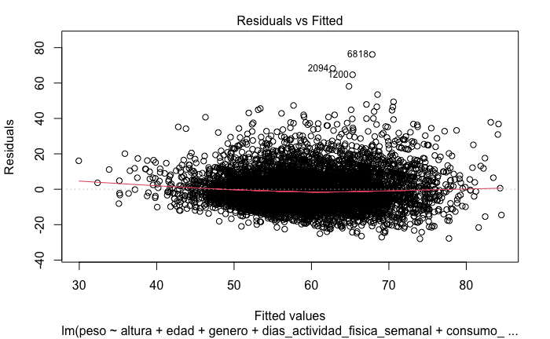

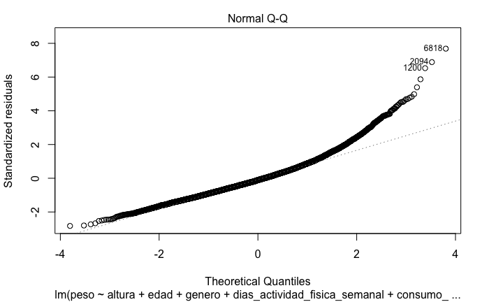

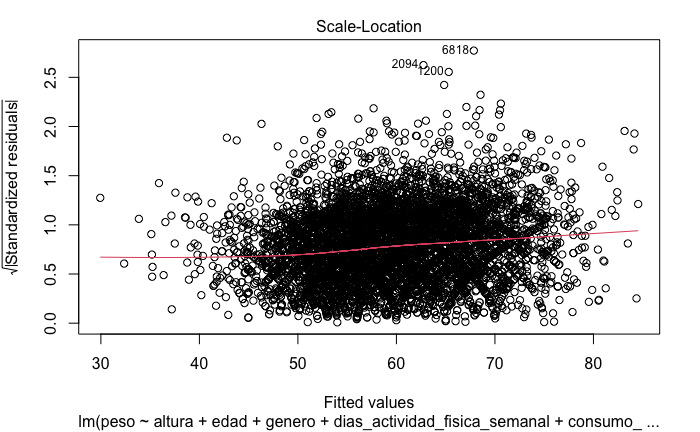

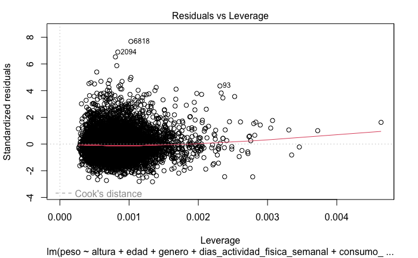

```r
plot(modelo_inicial)
```

### Conclusiones

Analizando los gráficos podemos obtener las siguientes conclusiones:

- **Residuos vs valores predichos**: No parece existir alguna estructura en los datos que esté afectando en la curva de predicción. Se observan algunos valores atípicos que mueven ligeramente la curva, pero no son significativos.
- **Normal Q-Q plot**: el extremo inferior parece ajustarse a la curva normal, en cambio el extremo superio tiene una clara tendencia que la aleja de la curva normal. Vemos que la presencia de los outliers que se detectaron en el gráfico de residuos, son los principales causantes de este desvío, pero no son los únicos culpables.
- **Residual vs leverage**: Se detectan algunos residuos que influencia en la curva de Leverage, pero no parecen estár afectando significativamente al Leverage.

# Modelo Robusto

Leer el archivo “encuesta_salud_modelo6.csv”. Este último consiste en el dataset original de train con la incorporación de algunas observaciones adicionales que pueden incluir valores atípicos. En particular, observar la relación entre peso y altura ¿Qué ocurre con estos nuevos datos?

Entrenar el modelo inicial con estos nuevos datos y comentar qué se observa en los coeficientes estimados y las métricas de evaluación (R cuadrado ajustado, RMSE y MAE) respecto al modelo entrenado con el set de entrenamiento original.

Entrenar un modelo robusto con la misma especificación que el modelo inicial sobre los nuevos datos. Comparar los coeficientes y su performance (RMSE y MAE) respecto al modelo inicial no robusto entrenado en este punto. ¿Qué puede concluir al respecto?

Nota: los registros que se suman en este punto son observaciones ficticias que se generaron a partir de observaciones reales del set de datos original.

```r
# Cargo el nuevo dataset
encuesta_salud_modelo6_df <- read.csv("datasets/encuesta_salud_modelo6.csv")

# Genero un data frame con las variables numéricas
numeric_6_df = encuesta_salud_modelo6_df %>% dplyr::select(where(is.numeric))
numeric_6_df = numeric_df[, ! names(numeric_df) %in% c("record"), drop = F]
numeric_6_df["genero"] = encuesta_salud_modelo6_df["genero"]
```

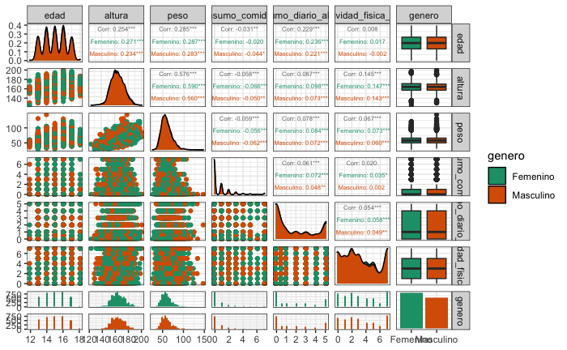

```r
# graficamos con ggpairs coloreando por property type
g <- ggpairs(numeric_6_df, aes(color = genero),
          upper = list(continuous = wrap("cor", size = 2, hjust=0.5)), legend = 25, progress=FALSE) +
  theme(axis.text.x = element_text(angle = 90, hjust = 1), legend.position = "bottom") +
  theme_bw()
# hacemos un loop para cambiar los colores del gráfico
for(i in 1:g$nrow) {
  for(j in 1:g$ncol){
    g[i,j] <- g[i,j] +
      scale_fill_brewer(palette="Dark2") +
      scale_color_brewer(palette="Dark2")
        }
}
g
```

Analizando las variables del nuevo dataset vemos que no se detectan diferencias entre los valores medios de altura, peso y dias_actividad_fisica al compararlos por género, lo cual nos está indicando que los outliers o valores atípicos introducidis en este dataset, están afectando la influencia de la variable género que era una variable muy importante en los modelos generados hasta el momento.

#### Modelo inicial

$$\begin{align*}
E(peso) = \beta_0 + \beta_1 altura + \beta_2 edad + \beta_3 genero +
\beta_4 diasActividadFisicaSemanal + \beta_5 consumoDiarioAlcohol
\end{align*}$$

```r
# ajustamos el modelo lineal múltiple
modelo_inicial_no_robusto = lm(formula = peso ~ altura + edad + genero + dias_actividad_fisica_semanal + consumo_diario_alcohol, data = encuesta_salud_modelo6_df)

# Resumen del modelo
tidy(modelo_inicial_no_robusto, conf.int = TRUE)
```

| term | estimate | std.error | statistic | p.value | conf.low | conf.high |
| --- | --- | --- | --- | --- | --- | --- |
| (Intercept) | -26.287100145 | 3.66136550 | -7.17958918 | 7.699589e-13 | -33.4644643 | -19.10973602 |
| altura | 0.352009084 | 0.02238090 | 15.72810146 | 8.057977e-55 | 0.3081359 | 0.39588230 |
| edad | 1.868589873 | 0.14774056 | 12.64777855 | 2.819189e-36 | 1.5789745 | 2.15820526 |
| generoMasculino | 3.313052885 | 0.42922377 | 7.71870791 | 1.335653e-14 | 2.4716468 | 4.15445898 |
| dias_actividad_fisica_semanal | -0.102125141 | 0.07861965 | -1.29897728 | 1.939938e-01 | -0.2562430 | 0.05199273 |
| consumo_diario_alcohol | 0.003719619 | 0.09693488 | 0.03837235 | 9.693919e-01 | -0.1863015 | 0.19374077 |

```r
summary(modelo_inicial_no_robusto)
```

```
Call:
lm(formula = peso ~ altura + edad + genero + dias_actividad_fisica_semanal +
    consumo_diario_alcohol, data = encuesta_salud_modelo6_df)

Residuals:
    Min      1Q  Median      3Q     Max
-27.758  -8.215  -2.613   3.996 121.161

Coefficients:
                               Estimate Std. Error t value Pr(>|t|)
(Intercept)                   -26.28710    3.66137  -7.180 7.70e-13 ***
altura                          0.35201    0.02238  15.728  < 2e-16 ***
edad                            1.86859    0.14774  12.648  < 2e-16 ***
generoMasculino                 3.31305    0.42922   7.719 1.34e-14 ***
dias_actividad_fisica_semanal  -0.10212    0.07862  -1.299    0.194
consumo_diario_alcohol          0.00372    0.09693   0.038    0.969
---
Signif. codes:  0 ‘***’ 0.001 ‘**’ 0.01 ‘*’ 0.05 ‘.’ 0.1 ‘ ’ 1

Residual standard error: 15.75 on 7123 degrees of freedom
Multiple R-squared:  0.1101,    Adjusted R-squared:  0.1095
F-statistic: 176.3 on 5 and 7123 DF,  p-value: < 2.2e-16
```

El valor de $R^2$ bajó drásticamente de 0.35 a 0.11

El estadístico F sigue siendo significativo.

## Comparación de modelos

Obtenemos las métricas de ambos modelos iniciales:

```r
initial_models_list <- list(modelo_inicial = modelo_inicial, modelo_inicial_no_robusto = modelo_inicial_no_robusto)

# Aplicamos la función augment a los modelos iniciales
initial_models = map(.x = initial_models_list, .f = augment)

# Obtenemos el RMSE para los 4 modelos
map_df(.x = initial_models, .f = metrics, truth = peso, estimate = .fitted, .id="modelo") %>% arrange(.metric,.estimate)
```

| modelo | .metric | .estimator | .estimate |
| --- | --- | --- | --- |
| modelo_inicial | mae | standard | 7.4552017 |
| modelo_inicial_no_robusto | mae | standard | 9.2331458 |
| modelo_inicial | rmse | standard | 9.9101379 |
| modelo_inicial_no_robusto | rmse | standard | 15.7448988 |
| modelo_inicial_no_robusto | rsq | standard | 0.1100997 |
| modelo_inicial | rsq | standard | 0.3543754 |

Podemos observar que todos los valores empeoran drásticamente al utilizar el nuevo dataset.

- **MAE**: incrementó de 7.455 a 9.233 (24%)
- **RMSE**: incrementó de 9.91 a 15.744 (59%)
- **$R^2$**: disminuyó de 0.354 a 0.11

## Modelo robusto

```r
# ajustamos el modelo lineal múltiple
modelo_inicial_robusto = rlm(formula = peso ~ altura + edad + genero + dias_actividad_fisica_semanal + consumo_diario_alcohol, data = encuesta_salud_modelo6_df)
```

```r
# Resumen del modelo no robusto
summary(modelo_inicial_no_robusto)
```

```
Call:
lm(formula = peso ~ altura + edad + genero + dias_actividad_fisica_semanal +
    consumo_diario_alcohol, data = encuesta_salud_modelo6_df)

Residuals:
    Min      1Q  Median      3Q     Max
-27.758  -8.215  -2.613   3.996 121.161

Coefficients:
                               Estimate Std. Error t value Pr(>|t|)
(Intercept)                   -26.28710    3.66137  -7.180 7.70e-13 ***
altura                          0.35201    0.02238  15.728  < 2e-16 ***
edad                            1.86859    0.14774  12.648  < 2e-16 ***
generoMasculino                 3.31305    0.42922   7.719 1.34e-14 ***
dias_actividad_fisica_semanal  -0.10212    0.07862  -1.299    0.194
consumo_diario_alcohol          0.00372    0.09693   0.038    0.969
---
Signif. codes:  0 ‘***’ 0.001 ‘**’ 0.01 ‘*’ 0.05 ‘.’ 0.1 ‘ ’ 1

Residual standard error: 15.75 on 7123 degrees of freedom
Multiple R-squared:  0.1101,    Adjusted R-squared:  0.1095
F-statistic: 176.3 on 5 and 7123 DF,  p-value: < 2.2e-16
```

```r
summary(modelo_inicial_no_robusto)$sigma
```

```
[1] 15.75153
```

```r
# Resumen del modelo robusto
summary(modelo_inicial_robusto)
```

```
Call: rlm(formula = peso ~ altura + edad + genero + dias_actividad_fisica_semanal +
    consumo_diario_alcohol, data = encuesta_salud_modelo6_df)
Residuals:
     Min       1Q   Median       3Q      Max
-26.4429  -5.8818  -0.4264   5.8326 126.3340

Coefficients:
                              Value    Std. Error t value
(Intercept)                   -59.8621   2.1418   -27.9494
altura                          0.5905   0.0131    45.1026
edad                            1.4090   0.0864    16.3033
generoMasculino                 1.4726   0.2511     5.8651
dias_actividad_fisica_semanal  -0.0587   0.0460    -1.2758
consumo_diario_alcohol          0.0138   0.0567     0.2430

Residual standard error: 8.684 on 7123 degrees of freedom
```

```r
summary(modelo_inicial_robusto)$sigma
```

```
[1] 8.684081
```

Ya podemos observar que el RSE del modelo robusto es mucho menor. Pasó de 15.7515 a 8.684

```r
initial_models_list_2 <- list(modelo_inicial_no_robusto = modelo_inicial_no_robusto, modelo_inicial_robusto = modelo_inicial_robusto)

# Aplicamos la función augment a los modelos iniciales
initial_models_2 = map(.x = initial_models_list_2, .f = augment)

# Obtenemos el RMSE para los 4 modelos
map_df(.x = initial_models_2, .f = metrics, truth = peso, estimate = .fitted, .id="modelo") %>% arrange(.metric,.estimate)
```

| modelo | .metric | .estimator | .estimate |
| --- | --- | --- | --- |
| modelo_inicial_robusto | mae | standard | 8.7590119 |
| modelo_inicial_no_robusto | mae | standard | 9.2331458 |
| modelo_inicial_no_robusto | rmse | standard | 15.7448988 |
| modelo_inicial_robusto | rmse | standard | 16.0040021 |
| modelo_inicial_robusto | rsq | standard | 0.1036958 |
| modelo_inicial_no_robusto | rsq | standard | 0.1100997 |

### Analisis de los gráficos

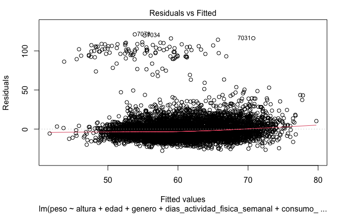

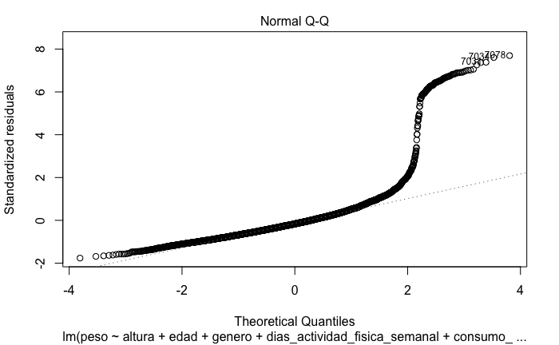

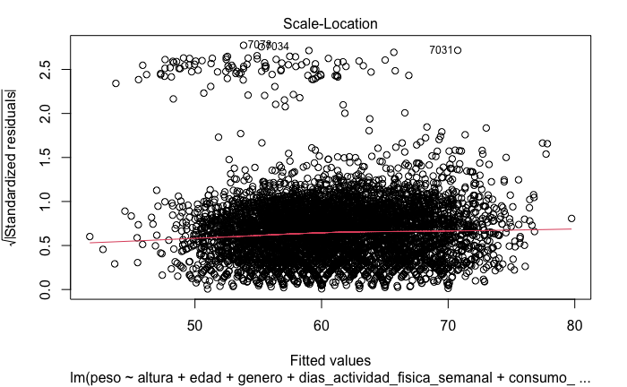

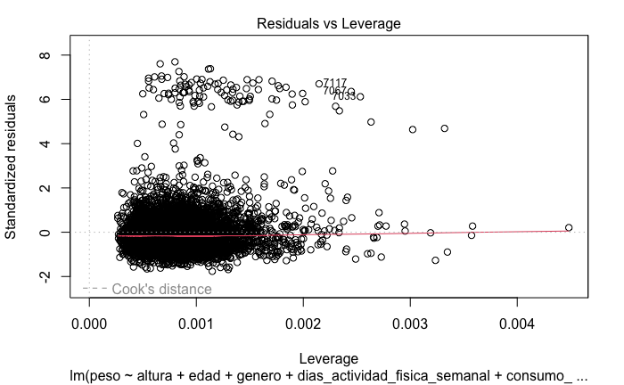

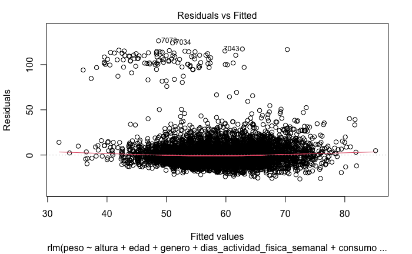

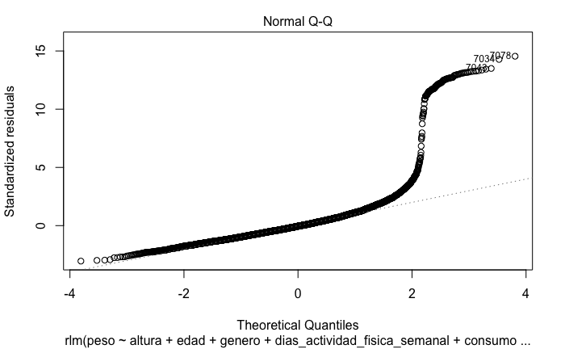

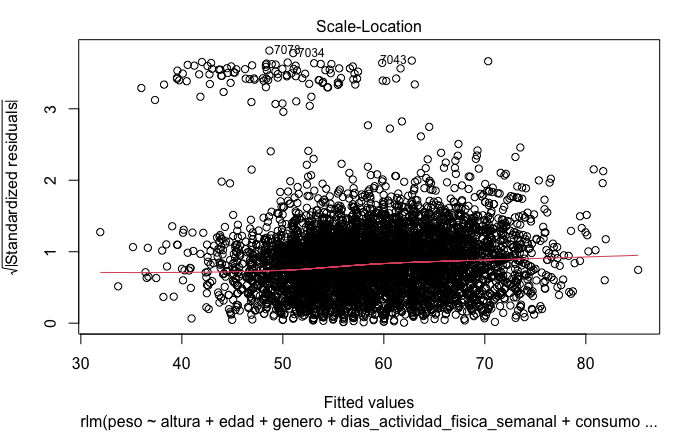

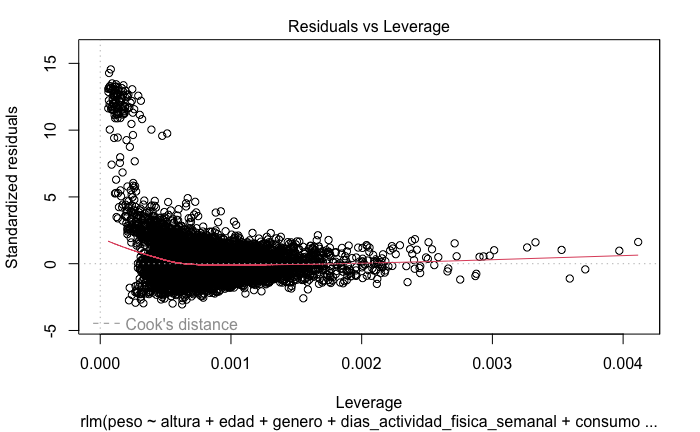

- No se observan diferencias significativas entre los residuos y los valores predichos, en cuanto a la distribución de los puntos.
- Sí se observa una diferencia en la distribución del Leverage. En el modelo robusto se observa una mayor concentración de los residuos sobre la curva del Leverage, lo que nos indica que es menos sensible a las variaciones de los valores atípicos que tenemos en el dataset.